# Chr18_SnpEff

Dave Speca

7/22/2017

#### Preliminaries

Exploratory analysis of SnpEff output indicated that SnpEff ANN= data is appended to the INFO column of the .vcf file (column #8), making it quite unwieldy. But I should be able to use dplyr to search for specific strings (variant calls) that have been added by SnpEff.

#### SnpEff analysis

N.B. I downloaded the latest version of SnpEff into my home directory. Then within the snpEff home directory I ran this command from the Terminal:

`java -Xmx4g -jar snpEff.jar mm10 Chr18/Chr18.all.vcf > Chr18.all.ann.vcf`

This (quite rapidly) generated the Chr18.all.ann.vcf file. N.B. Chr2.all.vcf was 18.9 Mb, Chr2.all.ann.vcf is 27.5 Mb, so this just adds additional columns of information. Then I started this new R_project (Chr18) after creating a git repository, and I moved the Chr18.all.ann.vcf file to the project’s directory.

The SnpEff annotations are contained within the “INFO” variable. I will need to extract them.

```r
library(ggplot2)
library(dplyr)
```

### Read in the vcf file and add headers of Chr18.all.ann.vcf:

```r
# read in .vcf file
Chr18.data <- read.table("Chr18.all.ann.vcf", as.is=TRUE, na.strings=".")
vcf.header <- system("grep '#C' Chr18.all.ann.vcf",intern = TRUE)
vcf.header <- sub("#","",vcf.header) #get rid of the pound sign
vcf.header <- unlist(strsplit(vcf.header,split="\t"))
colnames(Chr18.data) <- vcf.header
head(Chr18.data)
```

```
##   CHROM     POS ID                REF                    ALT      QUAL
## 1 chr18 3000211 NA                  A                      G 87.699300
## 2 chr18 3000271 NA                  A                      G  1.499270
## 3 chr18 3000281 NA TTTTGTTTGTTTGTTTGT TTTTGTTTGTTTGTTTGTTTGT  0.146981
## 4 chr18 3000323 NA                  A                      G 30.729600
## 5 chr18 3000345 NA                GTT                     GT 22.233900
## 6 chr18 3000371 NA                  T                      G 22.337700
##   FILTER
## 1     NA
## 2     NA
## 3     NA
## 4     NA
## 5     NA
## 6     NA
##                                                                                                                                                                                                                                                                                                          …
```

[output cut: 20 more lines]

### String split data

```r
# Before splitting add NAs to blank cells

Chr18.data$DBA[is.na(Chr18.data$DBA)] <- "NA:NA:NA:NA:NA:NA:NA:NA"

DBA.tmp <- matrix(
  unlist(strsplit(Chr18.data$DBA,split = ":")),
  nrow=nrow(Chr18.data),
  byrow=TRUE
  )
head(DBA.tmp)
```

```
##      [,1]  [,2] [,3]  [,4] [,5]  [,6] [,7]  [,8]
## [1,] "1/1" "4"  "0,4" "0"  "0"   "4"  "103" "-9.52543,-1.20412,0"
## [2,] "0/1" "6"  "3,3" "3"  "46"  "3"  "94"  "-1.7322,0,-2.48708"
## [3,] "0/1" "6"  "3,3" "3"  "111" "3"  "39"  "-0.474718,0,-7.94468"
## [4,] "0/1" "10" "4,6" "4"  "98"  "6"  "187" "-5.852,0,-5.8895"
## [5,] "0/1" "11" "5,6" "5"  "106" "6"  "196" "-5.81838,0,-6.43519"
## [6,] "0/1" "9"  "3,6" "3"  "95"  "6"  "204" "-6.33152,0,-5.9801"
```

```r
colnames(DBA.tmp) <- paste("DBA",c("gt","tot.depth","NObsAllele", "ref.depth","ref.qual","alt.depth","alt.qual","gen.lik"),sep="_")

Chr18.data$Chr18[is.na(Chr18.data$Chr18)] <- "NA:NA:NA:NA:NA:NA:NA:NA"

Chr18.tmp <- matrix(
  unlist(strsplit(Chr18.data$Chr18,split = ":")),
  nrow=nrow(Chr18.data),
  byrow=TRUE
  )
head(Chr18.tmp)
```

```
##      [,1]  [,2] [,3]  [,4] [,5]  [,6] [,7] [,8]
## [1,] "0/1" "2"  "1,1" "1"  "37"  "1"  "41" "-3.48099,0,-3.09577"
## [2,] "0/1" "2"  "1,1" "1"  "41"  "1"  "41" "-3.14406,0,-3.48099"
## [3,] "0/1" "2"  "1,1" "1"  "41"  "1"  "37" "-2.31947,0,-2.87893"
## [4,] "0/1" "4"  "3,1" "3"  "119" "1"  "41" "-2.542,0,-8.38775"
## [5,] "0/1" "5"  "4,1" "4"  "143" "1"  "41" "-2.24097,0,-10.2173"
## [6,] "0/1" "6"  "5,1" "5"  "201" "1"  "41" "-1.93994,0,-13.5856"
```

```r
colnames(Chr18.tmp) <- paste("Chr18",c("gt","tot.depth","NObsAllele", "ref.depth","ref.qual","alt.depth","alt.qual","gen.lik"),sep="_")

Chr18.data <- cbind(Chr18.data,DBA.tmp,Chr18.tmp,stringsAsFactors=FALSE)
summary(Chr18.data)
```

```
##     CHROM                POS              ID              REF
##  Length:45487       Min.   : 3000211   Mode:logical   Length:45487
##  Class :character   1st Qu.:31737802   NA's:45487     Class :character
##  Mode  :character   Median :46565950                  Mode  :character
##                     Mean   :47544774
##                     3rd Qu.:67713256
##                     Max.   :90602578
##      ALT                 QUAL           FILTER            INFO
##  Length:45487       Min.   :    0.00   Mode:logical   Length:45487
##  Class :character   1st Qu.:   22.99   NA's:45487     Class :character
##  Mode  :character   Median :   64.36                  Mode  :character
##                     Mean   :  457.15
##                     3rd Qu.:  127.27
##                     Max.   :71330.70
##     FORMAT              DBA               Chr18
##  Length:45487       Length:45487       Length:45487
##  Class :character   Class :character   Class :character
##  Mode  :character   Mode  :character   Mode  :character
##
##
##
##     DBA_gt          DBA_tot.depth      DBA_NObsAllele
##  Length:45487       Length:45487       Length:45487
##  Class :character   Class :character   Class :character
##  Mode  :character   Mode  :character   Mode  :character
##
##
##
##  DBA_ref.depth      DBA_ref.qual       DBA_alt.depth
##  Length:45487       Length:45487       Length:45487
##  Class :character   Class :character   Class :character
##  Mode  :character   Mode  :character   Mode  :character
##
##
##
##  DBA_alt.qual       DBA_gen.lik          Chr18_gt
##  Length:45487       Length:45487       Length:45487
##  Class :character   Class :character   Class :character
##  Mode  :character   Mode  :character   Mode  :character
##
```

[output cut: 8 more lines]

```
##
##  Chr18_ref.qual     Chr18_alt.depth    Chr18_alt.qual
##  Length:45487       Length:45487       Length:45487
##  Class :character   Class :character   Class :character
##  Mode  :character   Mode  :character   Mode  :character
##
##
##
##  Chr18_gen.lik
##  Length:45487
##  Class :character
##  Mode  :character
##
##
##
```

### Convert columns back to numeric:

```r
Chr18.data[,c("DBA_tot.depth","DBA_ref.depth","DBA_ref.qual","DBA_alt.depth","DBA_alt.qual",
            "Chr18_tot.depth","Chr18_ref.depth","Chr18_ref.qual","Chr18_alt.depth","Chr18_alt.qual")] <-
  apply(Chr18.data[,c("DBA_tot.depth","DBA_ref.depth","DBA_ref.qual","DBA_alt.depth","DBA_alt.qual",
            "Chr18_tot.depth","Chr18_ref.depth","Chr18_ref.qual","Chr18_alt.depth","Chr18_alt.qual")],
        2,
        as.numeric
        )
head(Chr18.data, 6)
```

```
##   CHROM     POS ID                REF                    ALT      QUAL
## 1 chr18 3000211 NA                  A                      G 87.699300
## 2 chr18 3000271 NA                  A                      G  1.499270
## 3 chr18 3000281 NA TTTTGTTTGTTTGTTTGT TTTTGTTTGTTTGTTTGTTTGT  0.146981
## 4 chr18 3000323 NA                  A                      G 30.729600
## 5 chr18 3000345 NA                GTT                     GT 22.233900
## 6 chr18 3000371 NA                  T                      G 22.337700
##   FILTER
## 1     NA
## 2     NA
## 3     NA
## 4     NA
## 5     NA
## 6     NA
##                                                                                                                                                                                                                                                                                                          …
```

[output cut: 48 more lines]

### Subset Chr18.data QUAL > 40

```r
# subset data keeping only SNPs with quality scores greater than or equal to 40
Chr18.Q40.data <- subset(Chr18.data, QUAL >= 40)
```

### Make it a little more user-friendly

```r
Chr18.Q40.tidy.data <-select(Chr18.Q40.data, -ID, -FILTER, -FORMAT, -DBA, -Chr18, -DBA_gen.lik, -Chr18_gen.lik, -DBA_NObsAllele, -Chr18_NObsAllele)
```

### Plot Chr18 congenic-specific SNPs (Chr18_gt==1/1) to define introgressed region

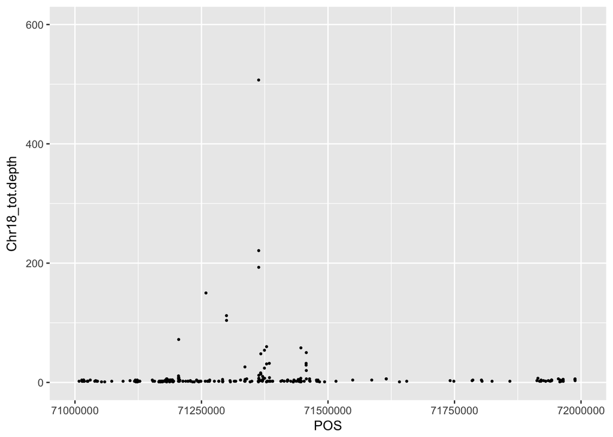

```r
###subset Chr18_gt=="1/1"
Chr18.XX11.data <- subset(Chr18.Q40.tidy.data, Chr18_gt=="1/1")
###plot these SNPs using total depth on y-axis and position on x-axis
plot.snps <- ggplot(Chr18.XX11.data , aes(x=POS, y=Chr18_tot.depth)) + geom_point(size = 0.5) + ylim(0,600) + xlim(7.1e+7, 7.2e+7)
plot.snps
```

### It looks like the introgressed region is safely in between 12.0 Mb and ~75.0 Mb. Epg5 is at ~77.9 Mb in mm10.

### **Upon closer inspection, it appears that the Chr18_gt==“1/1” SNPs really drop off at ~71.5 Mb.**

```r
# subset SNPs between 12.0 and 75.0 Mb
Chr18.Q40.congenic.tidy.data <- filter(Chr18.Q40.tidy.data, POS > 12000000 & POS < 75000000)
```

### Let’s make a table!

```r
# count the numbers common and unique to each genotype
ftable(Chr18.Q40.congenic.tidy.data[,c("DBA_gt","Chr18_gt")])
```

```
##        Chr18_gt  0/0  0/1  0/2  0/3  1/1  1/2  1/3  2/2  3/3   NA
## DBA_gt
## 0/0                0  119    0    0  239    5    0    0    0    0
## 0/1              373  491    3    0  530   15    0   11    0  214
## 0/2                0    2    0    0    9    2    3    0    0    0
## 0/3                0    0    0    0    0    1    0    0    0    0
## 1/1             1148  575   10    0 9220   71    0   28    0 7228
## 1/2               16   18    1    2   76   67    3    5    1   52
## 1/3                0    0    0    0    0    2    0    0    0    0
## 2/2                0    6    0    0   54    3    1    0    0    0
## 3/3                0    0    0    0    0    3    0    0    0    0
## NA                 0  151    0    0 5888   39    0    0    0    0
```

```r
# eliminate SNPs that are shared between DBA & Chr18
Chr18.FNL.data <- subset(Chr18.Q40.congenic.tidy.data,!(DBA_gt=="1/1" & Chr18_gt == "1/1"))
Chr18.FNL.data <- subset(Chr18.FNL.data, !(DBA_gt=="0/1" & Chr18_gt=="0/1"))
Chr18.FNL.data <- subset(Chr18.FNL.data, !(DBA_gt=="1/2" & Chr18_gt=="1/2"))
```

### Let’s start looking for meaningful variants!

```r
# get rid of intergenic_region & intron_variant
Chr18.InGene <- filter(Chr18.FNL.data, !grepl("intergenic_region|intron_variant", INFO))
```

### Based on Chr18_gt==“1/1” SNPs, the distal boundary of the congenic line is near chr18:71500000 (instead of 75000000), so many SNPs in Chr18.InGene can be ignored (focus only on the first 224 SNPs).

**Individual SNPs** #### chr18:35571975 (Matr3) is very convincingly “0/1” in DBA and “0/0” in Chr18. Double crossover + residual heterozygosity? Genomic range: ~20 kb. #### chr18:35861043 (Cxxc5). Low coverage, but noticeable “0/0” DBA and “1/1” Chr18 in 3’ UTR. There is a second SNP in Cxxc5 3’ UTR at chr18:35861057, which seems a little odd. #### chr18:36348782 (Cystm1) Convincingly “0/1” DBA and “0/0” Chr18 at many loci. #### chr18:46574304 (Ticam2) This is convincingly “0/0” in DBA and “1/1” in Chr18 in 5’ UTR. #### chr18:49697546 (Dtwd2) Very convincingly “0/1” at ~50 loci in DBA and “0/0” in Chr18 congenic. I am not sure what this means. Double crossover + residual heterozygosity? Genomic range: ~60 kb. #### chr18:66465483 (Pmaip1) – I dunno, maybe. #### chr18:71257402 (Dcc) – plausible candidate gene.

```r
# captain obvious DBA-gt=="0/0" & Chr18_gt=="1/1"
smokingGun <- subset(Chr18.InGene, DBA_gt=="0/0" & Chr18_gt=="1/1")
```

```r
# how many DBA coding SNPs (with HIGH scores) are there in the congenic?
Chr18.DBA <- subset(Chr18.Q40.congenic.tidy.data, DBA_gt=="1/1" & Chr18_gt=="1/1")
Chr18.DBA <- filter(Chr18.DBA, POS > 12000000 & POS < 71500000)
Chr18.DBA <- filter(Chr18.DBA, grepl("HIGH", INFO))
```

#### chr18:34221481 (non-coding RNA), splice variant mutation.

#### chr18:37764110 (Pcdhgb8, protocadherin), splice variant mutation.

**Not many strong coding mutations in this region (a bit surprising).

```r
# a closer look at all of the HIGH calls in Chr18.InGene
HIGH <- subset(Chr18.InGene, grepl("HIGH", INFO))
```